# In the Company of Strangers: Social Influence from Anonymous Peers in Online Game Settings

Converted from PDF `Jo-AnonymousPeerInfluence-2025-JCR.pdf` · 24 pages · anchors: page `#pN`, block `#pN-bK`

Page 1

## **In the Company of Strangers: Social Influence from Anonymous Peers in Online Game Settings**

WOOYONG JO SARANG SUNDER JEONGHYE CHOI MINAKSHI TRIVEDI

Social interactions among consumers, especially in the consumption of digital goods, have become commonplace in an increasingly interconnected market place. As such, understanding the impact of such interactions on consumer behavior carries major academic and practitioner significance. This research focuses on an important but under-researched aspect of social influence and the underlying mechanisms that may be driving peer effects. Using the context of a massive online peer-to-peer game, we estimate peer effects arising from anony mous peers. The findings suggest a robust and significant influence of anonymous peers on one’s own purchase behavior. Further, we find that peer effects arising from anonymous peers are largely driven by informational reasons as opposed to competitive concern even in a competitive online gaming context. That is, players rely on others’ purchase decisions despite anonymity; moreover, such influence is more pronounced for inexperienced players with little contextual knowledge. To demonstrate the effectiveness of leveraging the nature of peer influence in online game settings, we provide an illustrative example using an intervention simulation. Finally, we discuss the implications of our findings for marketing academia and practitioners in the video game industry.

*Keywords*: peer effects, social influence, informational influence, competitive con cern, video game

Wooyong Jo (wooyong@purdue.edu) is an assistant professor of mar keting at the Daniels School of Business, Purdue University, 403 Mitch Daniels Blvd., West Lafayette, IN 47907, USA. Sarang Sunder (sasunder@iu.edu) is an associate professor and Jerome Bess Faculty Fellow at the Kelley School of Business, Indiana University, 1275 E. 10th St, Bloomington, IN 47405, USA. Jeonghye Choi (jeonghye@yonsei.ac. kr) is a professor of marketing at the School of Business, Yonsei University, 50 Yonsei-ro, Seodaemun-gu, Seoul, South Korea. Minakshi Trivedi is a professor of marketing and J. Vaughn and Evelyne H. Wilson professor of business at the Neeley School of Business, Texas Christian University, 2900 Lubbock Ave., Fort Worth, TX 76109, USA. Please address correspondence to Jeonghye Choi. This article is based on the lead author’s master’s thesis in the Marketing program, completed under the supervision of the third author at Yonsei University. The authors thank

participants in this research’s presentations at Theory þ Practice in Marketing 2016 (Yonsei University), the University of Illinois—Chicago, the Korea Summer Workshop on Causal Inference 2022, and the College of Business at KAIST. This work was supported by the Yonsei University Research Grant of 2024. Supplementary materials are included in the web appendix accompanying the online version of this article.

*Editor: Andrew T. Stephen*

*Associate Editor: David A. Schweidel*

*Advance Access publication January 2, 2025*

© The Author(s) 2025. Published by Oxford University Press on behalf of Journal of Consumer Research, Inc.

All rights reserved. For permissions, please e-mail: journals.permissions@oup.com Vol. 00 2025

https://doi.org/10.1093/jcr/ucae075

1

Page 2

## **INTRODUCTION** H

uman beings are inherently social. Our daily lives are often defined by social interactions with friends, fam ily, as well as random happenstance interactions with strangers. Much of what is known about social interactions or social influence has to do with interactions with known peers, such as ties that individuals actively form with friends, colleagues, family, etc. (Goldenberg et al. 2009; Hartmann et al. 2008; Iyengar, Van den Bulte, and Valente 2011b; Sunder, Kim, and Yorkston 2019; Zhang and Godes 2018). However, one’s interactions need not only be con fined to *known* individuals. Often, people encounter ran dom strangers for brief moments of time. Such interactions are ubiquitous in offline settings (e.g., interactions with shoppers at retail stores, Uber drivers, service personnel, crowds at stadiums, etc.) and are ever increasing in online spaces such as gaming, metaverse, streaming, etc. (Bollinger et al. 2022; Gardete 2015; Lanz et al. 2019; Lusch 2017; McShane, Bradlow and Berger 2012; Shen, Malter and Rindfleisch 2023). Indeed, almost every online game released recently has a “social gaming” compo nent—one where players may collaborate with or compete against other players. For example, *Counter-Strike: Global Offensive* is a popular game where players collaborate toward a shared goal. Often these “teams” are formed by players being matched randomly with one another. On the other hand, *Chess.com* allows adversarial interactions where individuals compete against randomly chosen anon ymous opponents (Dean 2020). In fact, such one-on-one “random” matches have become a mainstay feature for most online games, including popular titles such as *Halo*, *Mortal Kombat*, *EA sports’ FIFA series*, etc. However, do such happenstance/random interactions actually influence individual behavior?

Given the ubiquitous nature of such interactions, espe cially in online settings, the potential influence of strangers on consumer behavior becomes a critically important ques tion from both an academic and managerial perspective. Surprisingly, however, there is a paucity of academic research investigating these effects in an online context, with little to no guidance on the theoretical underpinnings of these effects, especially from an empirical standpoint. While strangers can influence our behaviors in conven tional offline environments, much of what is known comes from experimental/survey-based analyses in offline con texts such as retail stores (Argo, Dahl, and Manchanda 2005; Blanchard, Dyachenko, and Kettle 2020; Ferraro, Bettman, and Chartrand 2009; Martin 2012). The few empirical works on the topic typically treat peer effects in the aggregate (e.g., crowd influences, new product diffu sion, etc.) and/or are focused on offline/durable goods con sumption (Bollinger et al. 2022; Bollinger and Gillingham 2012; Gardete 2015; McShane et al. 2012). Nevertheless, despite the prevalence of stranger interactions in online

contexts, there is no dedicated investigation into the role of strangers in online environments, *whether* such effects exist and *why*. This broadly forms the motivation for this research: to empirically document the effect of unknown individuals in an online gaming context, and, more impor tantly, to examine the underlying theoretical mechanisms that may be driving the effect.

The focus on identifying and empirically testing the underlying theoretical mechanisms is particularly important, both from a consumer behavior perspective and a manage rial one. Academic research on peer influence has proposed multiple mechanisms of social learning and normative influ ence. However, empirical research has been inconclusive regarding how the effects play out in the field, especially in the online context. Much of what we know comes from new product diffusion, offline settings, and durable goods con sumption. For instance, in the offline context, some have found that classical social influence theories, such as infor mational or normative influence, do not explain peer influ ence (Gardete 2015), while others have found evidence of status signaling (Hinz, Spann, and Hann 2015; Hu and Van den Bulte 2014), opinion leadership (Iyengar et al. 2011b), and information cascades (Bikhchandani, Hirshleifer, and Welch 1992; McShane et al. 2012). From a manager’s point of view, knowing the theoretical underpinnings of such peer effects helps to effectively leverage their impact in the field. The purpose of this article then is to extend our understand ing of social influence arising from stranger interactions to the online setting, especially given the prevalent consumer behavior and managerial focus on social consumption in online contexts.

Using purchase and game log data from a large (compet itive) multiplayer videogame, and leveraging key contex tual factors that enable empirical identification, we find robust evidence of the “stranger” effect in online purchase behavior. In terms of dollar value, a 10% increase in spend ing behavior among anonymous peers can lead to a 0.70% increase in the focal individual’s spending ($), highlighting the relevance of happenstance interactions between indi viduals in online contexts. Clearly, strangers do indeed have a profound effect on consumer behavior.

More importantly, we develop and empirically test two potential mechanisms that may underlie peer effects— informational influence and competitive concern. Contrary to expectations, given the adversarial nature of the focal game, we find that the primary mechanism is not a concern with winning or losing but, rather, the perceived informa tional value in others’ purchases. That is, individuals rely on the informational value embedded in peer behaviors regardless of anonymity to inform their own decisions.

Another set of analyses reveals more precise pathways through which informational influence or social learning occurs. Specifically, we divide peers’ use of paid game items into two categories based on salience (i.e., the ease of item visibility to peers) and examine which group of

2 JOURNAL OF CONSUMER RESEARCH

Page 3

items affects players’ purchase decisions. We find that social learning is more pronounced when users are exposed to peers’ use of more salient game items—a nod to prior work in offline contexts on peer influence and visibility (Bollinger et al. 2022; McShane et al. 2012; Rogers 1995).

In this research, we make two important contributions to the literature. *First*, we contribute to the peer effects and social influence literature by examining a unique type of social interactions that are happenstance/random. While some behavioral studies have considered the valence of con versations between close friends and distant acquaintances (Chen 2017; Dubois, Bonezzi, and De Angelis 2016), few studies have considered the consequences of interactions with anonymous peers on one’s purchase decisions. Prior empirical work in the area has mostly considered such inter actions only in the aggregate, that is, crowd or installed base effects (Bollinger et al. 2022; Bollinger and Gillingham 2012; Iyengar, Van den Bulte, and Lee 2015; McShane et al. 2012; Narayanan and Nair 2013; Sunder et al. 2019). This is the first research, to our knowledge, to empirically quantify the impact of such happenstance *online* interactions on behavior using observational data.

*Second*, and more importantly, this article contributes to the theory of social influence by discussing and empirically testing competing theoretical foundations of peer effects— an aspect that has received relatively little attention in the literature, with a few exceptions (Burt 1987; Hu and Van den Bulte 2014; Toker-Yildiz et al. 2017). We find that, even in an adversarial/competitive setting, strangers exert influence on others through the perceived information embedded in their purchases (the informational influence mechanism). Interestingly, we do not find evidence that competitive concern or status threat mechanisms drive peer effects. This finding has significance beyond academia. We show that managers, particularly video game and app developers, can leverage peer effects stemming from infor mational influence to implement creative game designs and targeted strategies that promote social consumption.

#### **LITERATURE AND THEORY**

#### The Influence of Strangers

While the effect of peers on an individual’s behavior has been extensively studied in marketing, management, eco nomics, and other social science disciplines (Ameri, Honka, and Xie 2019; Du and Kamakura 2011; Gardete 2015; Hu and Van den Bulte 2014; Iyengar et al. 2015; McShane et al. 2012; Zhang 2010), the focus of our research is on the literature addressing *strangers*’ peer influence. Unlike the aggregate crowd and known peers, behaviors of *anonymous peers* (or strangers) are distinct in that the agents do not have prior relationships and have lit tle chance of interacting again in the future. Their opinions may not be reflective of the overall community or local

neighborhood (Ameri et al. 2019; Du and Kamakura 2011; Sunder et al. 2019) and they are less likely to exert the influence required to comply with social norms. As such, strangers’ social influence may be uniquely different from the aggregate crowd or known peer effects highlighted in prior works (Bollinger et al. 2022; Iyengar et al. 2015; McShane et al. 2012; Narayanan and Nair 2013). Furthermore, anonymous peers or strangers, unlike friends, may not share product preferences (Zhang, Liu, and Chen 2015) or mutual trust (Zhang and Godes 2018). It is unclear then whether conventional theories on social influence would apply in the case of stranger interactions. Figure 1 describes the conceptual differences in the peer effect liter ature. Note that our focus is on the middle box of figure 1— the impact of strangers on behavior in online settings.

A small stream of work—much of it conceptual— explores interactions with strangers. In a conceptual piece, Lusch (2017) suggests that individuals may be influenced by day-to-day interactions with strangers (such as taking a flight, checking into a hotel, etc.), a sentiment also echoed strongly in digital contexts by Shen et al. (2023). Much of what is known about the effects of stranger interactions comes from behavioral work in offline contexts (such as retail). For example, Argo et al. (2005) demonstrate that consumers’ emotions and self-presentation behaviors may be governed by the presence of strangers in a retail environ ment. Chen (2017) shows that consumers tend to self- enhance when communicating with strangers, as opposed to connecting emotionally (e.g., sharing personal events) with friends. Consumers may also modify their consumption pat terns in the presence of strangers. Ferraro et al. (2009) show, through a series of experiments, that consumers are more likely to choose a brand when they see a stranger using the same brand. While interactions with friends or known peers may be governed by communal norms such as interdepend ence and reciprocity, interactions with strangers may be gov erned by exchange norms such as self-interest (Clark and Mills 1979). Empirical work studying the role of strangers largely comes from offline contexts. Gardete (2015) explores peer effects in offline purchase behavior using data from airline purchases. In the durable goods market, McShane et al. (2012) find significant peer effects largely driven by visibility, a result that was also evident in the adoption of solar technology (Bollinger et al. 2022).

In online contexts, much of what is known about peer influence comes from studying “friend” networks or known peers (see table 1 for a selected review of recent literature). As we elaborate above, influence from known peers is likely to be different compared to happenstance online interactions with strangers. Whether such interactions have an impact on consumer behavior (especially in an adversa rial gaming context) remains an open question. If such interactions do indeed influence behavior, the underlying theoretical mechanisms call for more research—a primary objective of this article.

JO ET AL. 3

Page 4

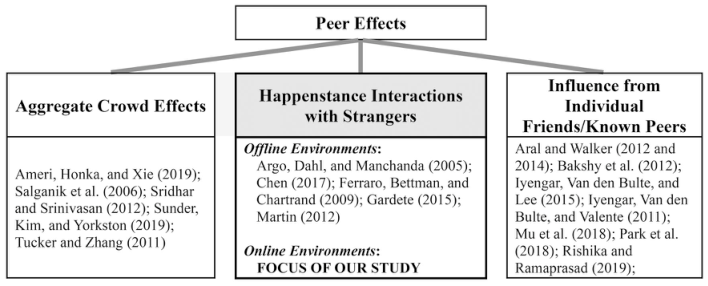

NOTE: figure/graphic rendered as an image from the PDF; its content is not machine-readable text. Caption (if any) follows as the next block.

#### Underlying Theoretical Mechanisms of Peer Effects

Numerous theories have been proposed to explain social influence (Deutsch and Gerard 1955; Van den Bulte and Lilien 2001). Broadly, the theoretical mechanisms driving peer effects may be classified into (1) informational influ ence (in which individuals infer quality signals through peer behaviors), (2) competitive concern (in which individ uals perceive a status/performance disadvantage in not complying with peer behaviors), (3) normative influence (in which individuals conform to and comply with in-group norms), and (4) network effects (in which benefits accrue as the number of peers increases). The institutional setup of our empirical context, a competitive one-on-one video game, is such that normative and network influence are unlikely. In the interest of completeness, however, we describe the mechanisms in brief below and discuss their relevance to the focal research context.

*Informational Influence.* Informational influence occurs when an individual relies on information from his/ her peers in an effort to reduce the uncertainty of an out come (Bikhchandani, Hirshleifer, and Welch 1998; Deutsch and Gerard 1955). As such, the informational influence or social learning mechanism suggests that peo ple learn from others’ actions and converge on similar behaviors. The impact of informational influence depends on the perceived value of the outcome and the credibility of the peer as a source. As a result, peer effects driven by social learning/informational influence are stronger when individuals perceive higher uncertainty and weaker when individuals are knowledgeable or are opinion leaders

(Iyengar et al. 2011b; Nair, Manchanda, and Bhatia 2010; Sunder et al. 2019). Thus, as individuals accrue contextual knowledge and expertise, they become more certain about their preferences/decisions and therefore may not need to rely on peers as much.

*Competitive Concern.* Another mechanism that offers a compelling rationale for social influence (especially in a competitive context) is the role of competitive concern. Purchases or innovation adoptions by one’s opponents may offer a competitive edge unless one adopts as well, which can lead to peer effects driven by competitive concern (Burt 1987; Hannan and McDowell 1987; Jo 2017; Van den Bulte and Lilien 2001; Van den Bulte and Wuyts 2009). Early applications come from studies focused on innovation adoption (Burt 1987; Hannan and McDowell 1984a, 1984b, 1987), where an agent’s adoption decision is modeled as a function of previous “*structurally equivalent*” (or similar) peers’ decisions. Relatedly, competitive con cern can also stem from status signaling behavior; that is, when an individual’s social status or position within a social structure is threatened (Bronnenberg and Mela 2004; Toker-Yildiz et al. 2017; Van den Bulte and Lilien 2001). Indeed, these status effects may be nonlinear. Hu and Van den Bulte (2014) show that, in medical device adoption behavior, competitive concern is most pronounced for mid- status individuals due to anxiety associated with their status and conformity. In online contexts, Hinz et al. (2015) dem onstrate that conspicuous consumption increases social sta tus, and Lanz et al. (2019) take advantage of the effect when developing seeding strategies. Thus, if competitive concern is the primary mechanism driving peer effects,

**FIGURE 1**

THE TOPOLOGY OF PEER EFFECTS AND THE FOCUS OF THE CURRENT STUDY

4 JOURNAL OF CONSUMER RESEARCH

Page 5

**TABLE 1**

SELECTED WORKS STUDYING PEER EFFECTS IN ONLINE AND DIGITAL CONTEXTS

Reference

Context Dependent

variable Peer effects Key findings

Variable Source Nature of social interaction Mechanism

Ameri et al. (2019) Cartoon platform Cartoon series

viewing

decision

Rating, WOMa,

adoptions of peers

and crowd

Crowd and

known peers Non-adversarial None • Viewing decisions are driven

by community WOM and

peers’ adoption.

Aral and Walker

(2012) Social media Facebook app

adoption Notification of peers’

activities Known peers Non-adversarial None • Influence and susceptibility

vary by one’s age, gender,

and relationship status.

Aral and Walker

(2014) Social media Facebook app

adoption Notification of peers’

activities Known peers Non-adversarial None • Both tie strength and struc

tural embeddedness

increase peer effects.

Bakshy et al. (2012) Social media Clicks and likes to

AD Peers’ page like

status Known peers Non-adversarial None • Showing peers’ like status

increases the performance of

advertisement.

Gardete (2015)b In-flight

purchases Probability of

purchase Neighbor purchases Anonymous

peers Non-adversarial Inconclusive • Passengers are more likely

to make a purchase if a

neighbor does.

Park et al. (2018) Online video

game In-game

expenditure Peers’ game item

purchases Known peers Non-adversarial None • User experience reduces

(increases) peer effects on

functional (hedonic) game

items.

Peng et al. (2018) Social media Content sharing Common social

peers Known peers Non-adversarial None • Content from others with

common network peers is

more likely to be shared.

Rishika and

Ramaprasad

(2019)

Music platform Contribution

(song

favoriting)

Existence of social

ties Known peers Non-adversarial None • Magnitudes of peer effects

vary by structural embedded

ness and the strength of

social ties.

Salganik et al. (2006) Hypothetical

music market Content (song)

rating Number of

downloads Crowd Non-adversarial None • Crowd preference increases

inequality and unpredictabil

ity of music content.

Sun, Zhang, and Zhu

(2019) Social media Conformity to

peers’ choice Peers’ adoption rate

of color Known peers Non-adversarial None • Conformity to peers shows a

U-shaped pattern with the

proportion of adopters in the

network.

Sunder et al. (2019) Board gaming Product rating Average ratings of

peers & crowd Crowd and

known peers Non-adversarial None • User experience mitigates

(amplifies) the effect of

crowds (peers).

Current study Online video

game In-game

expenditure Peers’ game item

purchases Anonymous

peers Adversarial Yesc • Informational influence,

rather than competitive con

cern, operates between

anonymous peers in a com

petitive gaming context.

aWOM: Word-of-mouth.

bDespite its non-digital context, Gardete’s (2015) study is discussed due to its relevance to our research on significant anonymous peer effects.

cInformational influence and competitive concern.

JO ET AL. 5

Page 6

individuals facing greater challenges to their status may be more receptive to peer influence.

*Normative Influence and Network Effects.* Normative influence (or normative pressure) denotes a conformation to an in-group norm and expectation (Deutsch and Gerard 1955; Toker-Yildiz et al. 2017; Van den Bulte and Lilien 2001; Van den Bulte and Wuyts 2009). Examples of such pressures may include product choices (Wooten and Reed 2004) and sustainable behaviors (White and Simpson 2013), among others. Much of the research on normative pressures has its origins in conformity studies (Asch 1953), where normative influence occurs when there is a *pressure* to conform and a *cost* of deviating from the norm. Generally, the cost of divergence is amplified when mem bers belong to in-group networks (Bikhchandani et al. 1992). The stronger the in-group ties, the higher the pres sure to conform (Mackie and Cooper 1984) and the higher the barriers for dissention (Harmeling et al. 2017). Normative influence is unlikely in our setting because of the lack of strong in-group ties among users.<sup>1</sup>Players in the focal game rarely form friendships with others, and there are very few opportunities for the game’s community to exert influence on individual users. Similarly, network effects exist when there are shared benefits to individual behaviors such that an individual’s purchase would enhance the benefits for others in the social network. Such network effects do not operate in this competitive gaming setting. Thus, we rule out normative influence and network effects as potential mechanisms.

We therefore explore two main theoretical mechanisms that may be driving peer effects in this context—informa tional influence and competitive concern (note that we do empirically rule out “normative influence” in the Robustness Checks and Supplementary Analyses section). The above theoretical mechanisms are conceptually distinct, suggesting the need to distinguish them from an empirical standpoint. Next, we describe the empirical context and data that form the basis of our investigation. Following this, we discuss our strategy to identify anonymous peer effects using observatio nal data and then ascertain the underlying mechanisms through theory-driven empirical testing (Iyengar, Van den Bulte, and Choi 2011a).

#### **EMPIRICAL CONTEXT AND DATA**

#### Empirical Context: Online Video Game

The data come from one of the largest online game pub lishers in South Korea that wishes to remain anonymous.

The focal game is categorized as a sports management game in which users manage a baseball team (by designing ath letes, finances, contracts, coaching strategy, etc.). The data include individual-level playing and spending logs of 4,000 randomly drawn users for 8 months between July 2011 and February 2012 (32 weeks in total). The focal game is consid ered a freemium product where customers play for free but can make in-game purchases that may enhance performance (e.g., defense skill boosters) or change aesthetic features (e.g., uniforms or logo colors). There are a total of 63 unique game items that can be purchased (32 functional items that enhance performance and 31 that are aesthetic). More than 90% of the total observed revenues come from functional item purchases such as defense boosts and other perform ance enhancements. Once used in a game, the item expires and cannot be used again. The weekly proportion of users making voluntary purchases is about 14%, and conditional on making purchases, the average spending per purchase is $2.984, with the median being $3.

Players can enjoy the game in two modes: *single play* mode (played against bots) or *social play* mode (played against anonymous individual peers). By default, all players begin in the *single play* mode where they can choose from a curated list of teams and rebrand the team according to their own tastes. For instance, a player can manage the composi tion of the team, position team members, set up additional training for the team, and recruit promising rookies. The player’s team is automatically included to participate in a weekly virtual sports league (*single play*), and the players are rewarded based on their team’s performance. In the *social play* mode, players opt in to play one-on-one matches with other anonymous players. If a player opts in by clicking a queue for social matches, then the game server randomly matches her/him to another anonymous player that also wishes to have a social match.

The key difference between the social play mode and the single play mode is that in the former, players can interact with the opponent on a real-time basis. Since social matches are free for any player, they are quite popular. About 99% of our sample (4,000 players) participated in at least one social match during our observation period. On average, players participated in social matches for about 13.27 weeks out of the 32-week period, making the weekly average participation rate 41%. The game publisher pro vided detailed social match logs between players enabling us to track peer behaviors.<sup>2</sup>These logs contain complete information on all social matches stored on the game server, including data for players not included in our 4,000- user dataset. This allows us to construct an instrument (i.e., spending of peers’ peers) for identifying peer effects, 1 Sometimes, norms instituted by the game developer may exert norma tive influence, such as fair play standards and best practices. These “rules” are generally applicable to *all* gamers and unlikely to influence peer effects on an individual basis. As such, we expect there is little room for norms to be formed and subsequently conformed to in a one-on-one game match where players are randomly matched with opponents.

2 While we do observe the social match participation, our data do not include the outcome of each social match. This is due to a data purging policy instituted by the collaborating firm to reduce data/server man agement costs.

6 JOURNAL OF CONSUMER RESEARCH

Page 7

which we discuss further in the Methodology section. For conciseness, we use the term *peer effects* for the remainder of the article to describe the social influence exerted by anonymous players who have participated in social matches with the focal player.

Among the provided 4,000 randomly selected players, approximately 7.5% (301 players) have either missing IP addresses or birthday information, which is needed to cre ate control variables such as local weather and age. As a result, we primarily perform our analyses on the 3,699 players for whom we create all control variables. We aggregate the data to weekly levels to accommodate the infrequency of paid-item transactions while allowing for temporal variation at the granular level, resulting in 118,368 player-week observations. Doing the analysis at the weekly level is also appropriate because the virtual leagues are run on a weekly basis.<sup>3</sup>

#### Variable Operationalization

*Dependent Variable.* Our dependent variable of interest is the player’s in-game purchase behavior. As discussed earlier, players may make voluntary purchases on digital items that can improve team quality (utilitarian goods) or aesthetics (hedonic goods). We define Purchase $ ð Þ*it* as the dollar amount spent on in-game purchases by player *i* in week *t*. (Note that in our empirical model, we take the loga rithm of this variable to control for skewness, adding one to avoid the log-of-zero problem.)

*Independent Variables.* Our focus in this study is to understand the impact of peer effects (from anonymous players) on a focal player’s in-game purchase behavior. Following prior research (Bramoulle, Djebbari, and Fortin 2009; Goldsmith-Pinkham and Imbens 2013; Iyengar et al. 2011b; Jo 2017; Toker-Yildiz et al. 2017), we define the peer exposure variable, x*it*−1, as the weighted average of purchase amounts from anonymous peers that player *i* interacted with through social matches in week *t*–1.

**equation / math rendering (image)**

NOTE: contains mathematical notation; text above is the PDF text layer and symbols may be mis-extracted. Image shows the original.

interpretation of the estimated coefficient as elasticity holds unchanged. One critique of this measure is that it does not consider purchases made by peers in the distant past (e.g., week *t*–2 or *t*–3). In the robustness analyses, we relax this operationalization by replicating our analyses using alternative definitions of the peer exposure variable that account for peers’ purchases made in the distant past. Specifically, we replicate all models using a “peer exposure based on cumulative purchases,” which aggregates peers’ spending from previous weeks.

*Control Variables.* To account for player-level charac teristics, we generate a set of control variables based on player behaviors observed in the data. We include visit fre quency to the game made by each user in each week, the proportions of game play durations on weekends (Saturday to Sunday) and nights (between 6:00 PM and 6:00 AM), as well as demographic information such as gender, biological age, and the number of weeks since sign-up. Finally, we collect and add weekly precipitation (in millimeters) for each user using the Korea Meteorological Administration’s public data repository to account for potential shifts in game activity due to inclement weather conditions. Specifically, we collect local precipitation data from weather stations available in the public data repository and match it to the approximate geo-coordinates of players, using their IP addresses.

Table 2 reports the summary statistics of the variables, based on the sample of 3,699 users. On average, players sign into the game nine times and spend $4.89 on items each week. The average of the purchase amount by anony mous peers is about $4.08. This peer exposure originates from all anonymous peers with whom the focal user inter acted and may include players who are not part of our focal sample of 3,699 players. Notably, the SDs of the purchase behavior variables (own and peer) are relatively high. This is likely due to the infrequency of purchases in freemium- based video games.

#### Challenges in Identification of Peer Effects

Estimating *causal* peer effects using observational (nonexperimental) data faces three well-known challenges: endogenous group formation (i.e., homophily), simultane ity, and correlated unobservables (Manski 1993). In our setting, users may selectively choose to participate in social matches in a given week, introducing another layer of selection bias. We elaborate on these challenges and dis cuss our empirical approach to addressing them.

*Endogenous Group Formation.* Since individuals “. . . *with similar tastes may tend to form social groups*. . .” (Hartmann et al. 2008, 294), subsequent correlations in behaviors may be a consequence of commonly shared

3 For robustness, we replicate main analyses with the original 4,000 players but without the missing controls. We also replicate our analy ses on the top 1,131 players who account for 95% of the firm’s reve nues throughout the data period. These analyses are explained further in the Robustness Checks and Supplementary Analyses section.

JO ET AL. 7

Page 8

preferences, rather than causal peer effects. Evidence for this is quite prevalent in contexts involving physician net works (Iyengar et al. 2015; Nair et al. 2010), ratings (Sunder et al. 2019), as well as video gaming (Park et al. 2018). While social matches in our setting are designed to randomly pair players, there are several reasons to suspect that endogenous group formation could still occur. For instance, game users may opt to play social games at spe cific times of the day, thus matching with players who have similar time preferences. If purchase decisions are in part correlated with the time of gameplay (e.g., night-time gamers are heavy spenders), then endogeneity bias in group formation may still be a concern. Additionally, players of similar expertise levels (indicated by their tiers) may have varying propensities for joining the social match queue, which could also lead to endogenous group formation.

To examine this, we revisit the raw social match logs (conditional on social match participation) and plot the combinations of users’ tiers in panel A of figure 2. The user tier represents the rank of each player in the focal game, reflecting their performance. The figure suggests two insights. First, the plot shows that all kinds of tier com binations are present in social match logs (marked as black dots), confirming the firm’s description of social matches where all kinds of matches are possible. Second, however, when we draw the contour lines of density (in blue), they indicate frequent matches along the 45-degree line of the map (see web appendix A1 for a heatmap figure). While part of this can be the result of a high concentration of players in the middle tiers (between tiers 4 and 12, as revealed by marginal distributions), these high-density areas may suggest that even though the firm’s pairing strat egy is purportedly random, the actual data patterns suggest the social matches are not entirely randomly determined.

There may be other confounding factors influencing the formation of peer groups. In panel B of figure 2, we also compute the distribution of cases where players are matched with the same tiers (jDiffj ¼ 0), one- or two-tier differences (jDiffj ¼ 1 or 2), and more than two tier

differences (jDiffj *>* 2). As shown in panel B, a significant portion of social matches occur with opponents of the same tier (37.18%), which motivates us to directly address the potential endogenous formation of social matches.

To address this issue, we exploit the availability of intransitive triads or partially overlapping pairs of ties in a player’s network to create exclusion restrictions (Bramoulle et al. 2009). The intuition behind intransitive triads is that the characteristics of peers’ peers who are not in the focal player’s network can be viable instruments for peer exposure (Shi, Grewal, and Sridhar 2021; Sunder et al. 2019). Figure 3 is an illustration of this using a six-person network. If our goal is to estimate the causal effect of users B and C on A, then the behaviors of users D, E, and F (who are connected to B and C, but not to A) can be used as instruments. In our case, the behavior in question is pur chase amount. Therefore, we use as our instrument the average purchase amount of peers’ peers in week *t*–2 who have not interacted with the focal user.

In our application, we employ a control function techni que since it provides a more robust solution to the endoge neity problem than predicting the endogenous variable directly from the instrument (Papies, Ebbes, and Van Heerde 2017; Wooldridge 2015). This approach is also known for its efficiency in handling interaction terms of potentially endogenous variables, which we will perform in our subsequent analyses (Papies et al. 2017). Specifically, we derive the residual by regressing the endogenous varia ble (the peer effect variable) on an instrument and a set of control variables. Then, we include the residual (i.e., the control function) as an additional regressor in our main equation to account for the possible endogeneity of the peer effect variable. This approach further helps prevent the need for additional instrumental variables (IV, here after) in the presence of interacted endogenous variables (see web appendix B for details).

*Simultaneity and Correlated Unobservables.* Simultaneity or the reflection problem arises when a focal agent and others in the same reference group influence

**TABLE 2**

DESCRIPTIVE STATISTICS

[output not shown]

NOTE: table converted from PDF layout to HTML text; cell boundaries are reconstructed. See PDF if exact alignment matters.

NOTE.—*N* ¼ 118,368. To check for potential multicollinearity, we regress total purchases on the eight independent variables in table 2 and confirm that the maxi mum variance inflation factor (VIF) is 1.18, suggesting minimal concern regarding multicollinearity.

8 JOURNAL OF CONSUMER RESEARCH

Page 9

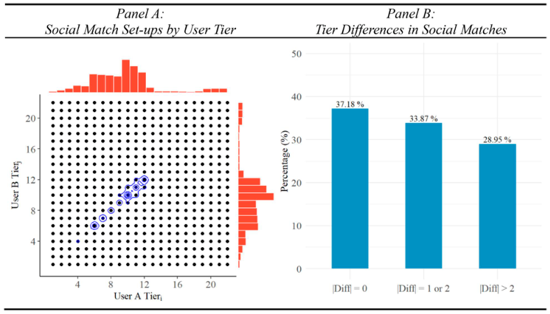

NOTE: figure/graphic rendered as an image from the PDF; its content is not machine-readable text. Caption (if any) follows as the next block.

each other simultaneously. To address this problem, we use the lagged variable of peer effects, Peer exposure*it*−1, to ensure the temporal ordering of cause and effect, following previous research (Ameri et al. 2019; Park et al. 2018; Toker-Yildiz et al. 2017). To address any remaining bias due to unobserved or omitted variables (Hartmann et al. 2008), we adopt a three-pronged approach. First, we include individual-level fixed effects to control for unob served heterogeneity at the player level (Nair et al. 2010). Second, we include weekly time-fixed effects to account for common shocks experienced by all players in each week. Lastly, to ensure robustness, we explore several alternative modeling strategies that account for heterogene ity, including the use of different functional forms, sam ples, and operationalizations (see the Robustness Checks and Supplementary Analyses section).

*Selection into Social Matches.* Finally, we have another layer in our context that may introduce selection biases. As we describe in the Empirical Context and Data section, players can freely participate in social matches. Therefore, the exposure to peers’ spending happens conditional on the focal player’s participation in a social match in a given

week. This may create an empirical issue if the decision to play social matches is endogenously determined. For instance, players of specific tiers may participate more in social matches than others, as evidenced in our data (see web appendix A2 for details). This selection issue can cre ate bias in the estimation. That is, zero values in the peer exposure variable (our independent variable of interest) could arise from two distinct processes: (1) the player did not participate in any social matches or (2) the player par ticipated in social matches but played only with peers who did not spend any money. These different sources of zeros could lead to biased estimates if not properly addressed. We explicitly address this issue by modeling a player’s decision to play social matches in each week using the Heckman-style estimation.

To account for one’s participation in social matches, we identify a valid IV that introduces quasi-random variation in the probability of participating social matches. That is, the instrument needs to influence one’s participation in social matches (i.e., relevance) but not purchase decisions (i.e., exclusion). We construct our IV by interacting two sources of variation: temporal and cross-sectional. For tem poral variation, we consider sudden shutdowns of the focal

**FIGURE 2**

SOCIAL MATCH SET-UPS BY USER EXPERTISE

NOTE.—Color is available online. Panel A plots the unique combinations of observed matches from social match logs, accompanied by density contour lines and mar ginal distributions. Panel B depicts the extent to which certain combinations of tier groups are observed, focusing on the absolute difference between them.

JO ET AL. 9

Page 10

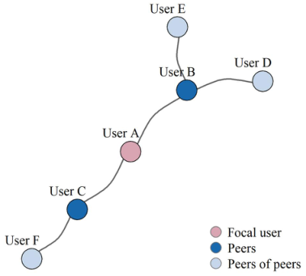

NOTE: figure/graphic rendered as an image from the PDF; its content is not machine-readable text. Caption (if any) follows as the next block.

video game service due to technical glitches or unexpected maintenance needs. During the 32-week observation period, we identify four instances of sudden server shut downs that prevented both single and social gameplay. These maintenance events lasted at least 8 hours, with the longest exceeding 12 hours. To minimize impact on users’ gameplay, the maintenance typically occurred at night but with urgent notice (e.g., midnight to 8 AM). We collect these data using the *Wayback Machine* (which archives his torical snapshots of web pages) and also by monitoring sudden announcements on the official website of the focal video game. We assign a value of one to weeks with unex pected server outages and a value of zero otherwise: *ServerDownt*. Our assumption is that a sudden shutdown in a particular week will significantly lower the likelihood of players participating in social matches. However, this vari able alone is insufficient to explain participation in social matches, as weekly time-fixed effects would absorb all the variation from this variable.

To complete our IV, we incorporate cross-sectional (user-level) information. Specifically, we compute each player’s night-time play tendency by dividing the number of play hours spent during the night (6:00 PM–6:00 AM) by the total hours of gameplay during our observation period: *NightPlayPortioni*. The overall distribution of this variable is approximately normal, with a mean of 0.585 and a SD of 0.161 (web appendix C). Importantly, only three players in the entire sample have a strictly zero value for this variable, which minimizes potential degenerate conditions (i.e., cases of no variation regardless of server

down events). We interact this variable with weekly main tenance downtime dummies to estimate whether a user has participated in social matches. The main identifying assumption here is that sudden maintenance shutdowns will significantly affect the social match participation of users who tend to play the game during night hours. However, we have no reason to expect that a sudden server shutdown would influence one’s spending patterns differ ently based on their time preference.<sup>4</sup>We use a random effects Probit model to estimate weekly social match par ticipation, using the constructed IV and a set of control var iables. Subsequently, we compute the inverse Mills ratio (IMR) and include it into the main equation. The results of this selection model and further details are available in web appendix C.<sup>5</sup>

While we have taken significant steps to address poten tial empirical challenges in estimating causal peer effects, it is important to acknowledge that our methods, while rig orous, are not without limitations compared to a

**FIGURE 3**

INTRANSITIVE PEER NETWORK

4 One potential concern is that the cross-sectional part of our IV, night-time play portion, may be partially endogenous due to its corre lation with spending propensity. However, such cross-sectional factors will be absorbed by player-level random effects included in the Probit model (see web appendix C for further discussion). 5 Interestingly, what may be considered a violation of the Stable Unit Treatment Value Assumption (SUTVA), due to users interfering with and influencing each other, is actually the focus of our research. Our research explicitly focuses on estimating these interference effects, making the setting fundamentally different from standard causal infer ence, such as policy impact evaluation. In this sense, we are leveraging the SUTVA violation to achieve the objective of our research.

10 JOURNAL OF CONSUMER RESEARCH

Page 11

randomized controlled experiment. For example, in an intransitive triad (figure 3), there is a possibility that focal user A and user D (the peer of a peer) may share common latent factors due to their overlap with peer user B. However, our use of user-level fixed effects substantially mitigates the impact of such factors. Additionally, as will be shown in the Results section, our analysis of the exclu sion restriction indicates that user D can only influence user A through peer B, further alleviating empirical con cerns. We emphasize that our results should be interpreted as causal peer effects, accounting for some common latent factors in peer exposures. In the Robustness Checks and Supplementary Analyses section, we thoroughly assess and address these potential limitations to ensure the robustness of our findings.

#### Estimation Equation

We use the following two-way fixed effects model for the main empirical specification (Nair et al. 2010).

*yit* ¼ *β*1Peer exposure*it −*1 þ **Xitγ** þ *ψIMRit −*1

þ *λε<sup>residual</sup>*

*it −*1 þ *αi* þ *τt* þ *εit*

#### **(1)**

where the dependent variable of interest, *yit*, is a log-scaled player’s purchase amount measured in dollars: log Purchase $ ð Þ*it* þ1

(Jo et al. 2020; Jo and Lewis 2024). Peer exposure*it*−1 is measured as the average purchase of player *i’*s peers made in week *t*–1 in logarithm (Iyengar et al. 2011b; Sunder et al. 2019; Toker-Yildiz et al. 2017). We take the logarithm of the peer effect variable *xit*−1 ð Þ after adding one to control for skewness: log x*it*−1 þ1 ð Þ. This also allows us to interpret the coefficient as an elastic ity. Specifically, β1 represents the change in one’s pur chases (in percentage) for every unit percentage point increase in peers’ purchases in the past week. **Xit** represents the vector of observable characteristics introduced in descriptive statistics and **γ** is the corresponding parameter vector. *IMRit*−1 represents the inverse Mills ratio, derived from the social match participation model, that accounts for bias arising from selective participation in social matches during certain weeks. ε*<sup>residual</sup>*

*it*−1 is a control function generated from the auxiliary regression and addresses potential endogeneity in the peer exposure conditional on social match participation. Player-level fixed effects, α*i;* account for unobserved but time-invariant heterogeneity and weekly time-fixed effects, τ*t*, absorb any temporal shocks shared by all players in each week. Finally, ε*it* denotes an error term and is assumed to be independently and identically distributed.

#### **RESULTS**

We first discuss the results from the first-stage models to validate our instrument. We then empirically address two

research questions arising from our focal issues—*whether* peer effects exist and *why*. Lastly, we provide the results of our comprehensive robustness analyses.

#### First-Stage Models

*Social Match Participation.* We estimate participation in social matches using a Probit model, which includes the instrument (based on *ServerDownt* ×*NightPlayPortioni*) along with the control variables, player-level random effects, and weekly time-fixed effects. The first regression reveals a negative and significant effect of the instrument on social match participation (β ¼ –0.319; *p <* .05). To evaluate weak instrument issues, we conduct a likelihood ratio test both with and without the instrument. Its inclusion significantly improves model fit (*p <* .01), suggesting that the instrument is not weak. To further validate our instru ment, we perform an exclusion restriction test as suggested in Barron, Kung, and Proserpio (2021). A sound instrument should influence the dependent variable only through affecting the endogenous variable. Therefore, if our instrument is valid, we would expect to see no change in purchase activities among players who did not participate in social matches in response to the instrument. To verify this, we regress the weekly purchase amount (the dependent variable of interest) on the instrument (*ServerDownt* ×*NightPlayPortioni*), focusing on player- week observations without social match participation. We find no significant relationship between our instrument and the dependent variable β ¼ 0*:*023; *p>:*10 ð Þ. This result supports the validity of our IV as a means of accounting for the selection process into social matches. Using the results of this regression, we compute the IMR and include it in the main regression. Full results are reported in web appen dix C. Next, we discuss the first-stage regression results for the peer exposure variable.

*Extent of Peer Exposure.* As previously discussed, another source of endogeneity is the extent of peer expo sure a player receives, which we account for using variation created by partially overlapping pairs. We regress the endogenous variable, Peer exposure*it*−1, on a set of exogenous variables **Xit** ð Þ and the chosen instrument (spending behavior of peer’s peers). The first- stage regression explains substantial variation (*F*9*;*3698 ¼ 4*;*238*:*65;*p<:*001 and *R*<sup>2</sup>¼ 72.1%) with the effect of the instrument being positive and significant

β ¼ 0*:*5003; *p<:*001 ð Þ. Also, we find that the model fit (*R*<sup>2</sup>) increases by 7% upon inclusion of the instrument. We further confirm using the empirical validity test suggested by Sanderson and Windmeijer (2016) that the instrument is not weak (*p <* .001). Following Barron et al.’s (2021) approach, we exam ine the instrument’s impact on the focal user’s spending solely through its influence on peers’ spending, known as the exclusion restriction. We find that the instrument does

JO ET AL. 11

Page 12

not significantly influence the focal user’s spending (β ¼ 0.002; *p >*.10) when the value of Peer exposure*it*−1 is zero, thereby confirming the exclusion restriction. All esti mation results are available in web appendix C. The above analyses offer strong evidence of instrument relevance and exclusion. We include the control functions in the main estimation to assess the causal effect of strangers. Since the control function is an estimated quantity, we use boot strapped standard errors (Papies et al. 2017; Wooldridge 2015).

#### Research Question 1: Do Stranger Interactions Affect Purchase Behavior?

We report the estimation results of our main model in table 3. For robustness, we report the results for the follow ing operationalizations of peer effects: (1) average pur chase amount of peers (in log), (2) average purchase frequency of peers (in log), and (3) proportion of peers who made purchases (Iyengar et al. 2011b). We find posi tive and significant peer effects in our video game setting across all the reported models. Specifically, the results of model 1 in table 3 suggest that a 10% increase in the aver age purchase of peers leads to approximately a 0.70% increase in the focal player’s purchase in the following week β1 ¼ 0*:*07; *p<:*001 ð Þ. This pattern holds in alterna tive models with different scaling of peer effects. Regarding potential selection issues, we include the IMR and the estimated control function. The estimate for the control function is statistically significant across all mod els, confirming the need to control for endogeneity bias.

#### Research Question 2: What Drives Peer Effects?

Recall that there are two competing theoretical mecha nisms that may drive peer effects—informational influence and competitive concern. We empirically test both and ascertain the dominant mechanism that drives peer effects arising from anonymous peers. We begin by discussing the test strategies for each mechanism and then provide the empirical findings.

*Test Strategy for Informational Influence.* Previous research defines informational influence as learning from others by updating one’s beliefs about the costs and bene fits of product adoption or purchase (Iyengar et al. 2015; Toker-Yildiz et al. 2017; Van den Bulte and Lilien 2001; Van den Bulte and Wuyts 2009). In other words, the more knowledgeable an individual is, the less likely they are to be susceptible to peer behaviors. Given that peer effects are driven by informational benefits, the extent of herding behavior should gradually disappear as players have less to learn from peers. We operationalize a player’s contextual knowledge in three different ways (Nokes and Ohlsson 2005). First, a player’s expertise may result from repeated activities or learning by doing (Nokes and Ohlsson 2005). As such, her expertise may be measured by the number of cumulative visits made to the game (first measure) and the number of cumulative social matches she participated in (second measure). Second, we consider a player’s tenure or time since sign-up as it can approximate the user’s knowl edge or expertise within the focal video game (third meas ure). To test the mechanism of informational influence, we interact these measures with the main peer effect

**TABLE 3**

PEER EFFECTS FROM ANONYMOUS PEERS

[output not shown]

NOTE: table converted from PDF layout to HTML text; cell boundaries are reconstructed. See PDF if exact alignment matters.

NOTE.—*N* ¼ 118,368. We use bootstrapped standard errors with 200 resamples. *p <* .05. *p <* .01. *p <* .001.

12 JOURNAL OF CONSUMER RESEARCH

Page 13

variable, Peer exposure*it*−1. A significant *negative* interac tion effect would confirm that informational influence is indeed at work.

*Test Strategy for Competitive Concern.* Competitive concern refers to one’s reaction to the disadvantage, threat, or concern imposed by a competitor’s product purchases or innovation adoptions (Burt 1987). Such concern is likely to be amplified when an individual perceives a threat to their social status (Bronnenberg and Mela 2004; Toker-Yildiz et al. 2017; Van den Bulte and Lilien 2001; Van den Bulte and Wuyts 2009). Extending this literature to our context, if competitive concern indeed operates, we would expect peer effects to be stronger when players compete against superior peer players (i.e., players in higher game tiers). The rationale is that when players compete against peers with superior gaming skills due to imbalances in the match ing process, they are more likely to lose than win, and possible failures may raise concerns about their social status (Behnke, Kosakowski, and Kaczmarek 2020). Thus, social interactions with superior players have the potential to amplify peer influence for competitive reasons. To examine this, we interact the main peer effect variable Peer exposure*it*−1 ð Þ with the proportion of social matches with peers of greater competence (% inferior matches*it*−1). Specifically, we determine the social match as an “inferior match” if the focal user’s game tier is lower than that of the opponent. By construction, the “inferior match” variable ranges between zero and one, with a mean of 0.149 and an SD of 0.227. A *positive* and significant interaction would then suggest competitive con cern as a potential mechanism for peer effects. For robust ness, we define inferior matches more strictly by using the tier gap between two players exceeding one and two (web appendix D).

*Results: informational Influence or Competitive Concern?.* To empirically test the competing underlying mechanisms of peer effects, we estimate the model with proposed interactions for both informational influence and competitive concern. Recall that we have three measures of “contextual knowledge” (for the informational influence mechanism). We estimate the model using all three combi nations of the different operationalizations. Table 4 pro vides a summary of the estimations, where each row represents a separately estimated model featuring a unique combination of operationalizations to ensure robustness. We present the full table and coefficients of all control var iables in web appendix D. This appendix also includes alternative operationalizations for competitive concern, wherein we define inferior matches more stringently by using the tier gap between two players, exceeding both one and two.

Table 4 offers three key insights. First, across all three models, we consistently observe a positive and significant main effect of peer exposure. This confirms the findings in table 3, indicating that exposure to peers’ spending does indeed motivate users to purchase more paid game items in subsequent weeks. Second, and more importantly, we observe a significant and negative moderation effect of one’s contextual knowledge, in support of the informa tional influence mechanism. This is consistent across all three models and suggests that the extent of peer influence diminishes as players acquire more contextual knowledge (i.e., possession of informational value), leading to reduced reliance on the behaviors of other players. Lastly, we did not find any significant moderation effects related to “threats to status” in any of the models.

To understand the magnitude of informational influence mechanism, we show the estimated peer effects at different percentiles of contextual knowledge using models 1–3 in table 4 (figure 4). We find that whereas the overall effects

**TABLE 4**

UNDERLYING MECHANISM TEST: INFORMATIONAL INFLUENCE VERSUS COMPETITIVE CONCERN

[output not shown]

NOTE: table converted from PDF layout to HTML text; cell boundaries are reconstructed. See PDF if exact alignment matters.

NOTE.—*N* ¼ 118,368. Each row represents one estimated model. Full results are available in web appendix D. We use bootstrapped standard errors with 200 resamples and these are provided in parentheses. *Rit−*1 is the tier of user *i* at week *t*–1 and *Rjt −*1 is the tier of user *j* (i.e., anonymous peer) at week *t*–1. All moder ators are centered on their means. *p <* .05. *p <* .01. *p <* .001.

JO ET AL. 13

Page 14

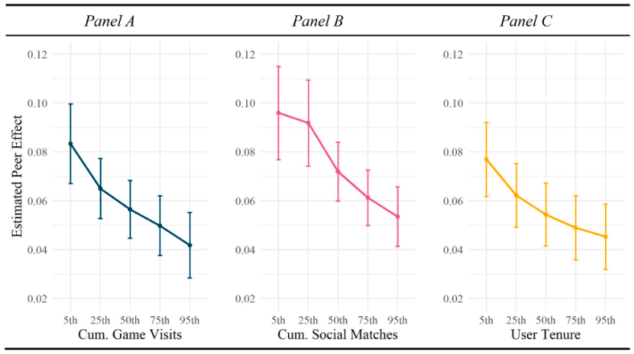

NOTE: figure/graphic rendered as an image from the PDF; its content is not machine-readable text. Caption (if any) follows as the next block.

of peers are positive and significant, the magnitudes decrease for those who have made more visits to the game (i.e., those who possess significant knowledge in the game), played more social matches, and have been signed up for a longer period. For example, the marginal peer effects decrease from 0.096 to 0.053, reducing by nearly half, when comparing the 5th and 95th percentiles of cumu lative social matches (figure 4, panel B). To summarize, these moderators provide strong evidence for informational influence as a theoretical mechanism.

#### Robustness Checks and Supplementary Analyses

We perform supplementary analyses to assess the robust ness of the findings and to explore additional insights. The list of analyses performed, along with the empirical reasons and related works, is summarized in table 5.

*Alternative Operationalizations of Peer Exposure and Moderators.* Previous research has operationalized peer effects in terms of the average of peer behaviors or propor tion of peers with adoptions or certain behaviors (Iyengar et al. 2011a, 2011b). As shown in table 3, we test the aver age of purchase frequency and proportion of peer behaviors

and find the results to be robust. In addition, we test various combinations of different operationalizations of moderators used in the mechanism tests to ensure robustness. These results are available in both table 4 and web appendix D.

*Alternative Operationalizations of Peer Exposure: A Dynamic Perspective.* Players’ usage of paid game items may not solely depend on purchases made in the previous week but could also originate from purchases made several weeks prior. To account for this, we construct a dynami cally aggregated peer exposure variable, employing a weekly discount factor similar to the advertising stock con cept commonly used in marketing literature (Jo and Lewis 2024). Specifically, we compute the stock of cumulative pur chases made by peer *j* up until week *t*-1 (see equation 2 below).

where λ is the discount factor for each week, we considered 1.0, 0.7, and 0.5 for robustness. We construct the peer

**TABLE 5**

OVERVIEW OF SUPPLEMENTARY ANALYSES

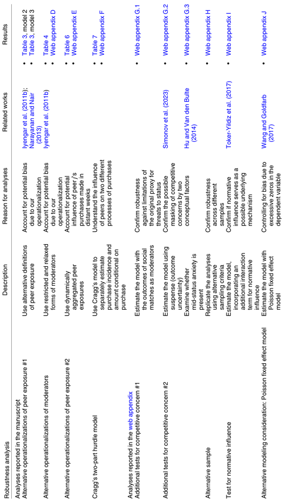

NOTE: complex table shown as an image of the PDF; the text below is a rough machine extraction and may be mis-aligned.

exposure variable by taking the average of the cumulative purchases of each peer that the focal user interacted with. We re-estimate the main model using the alternatively con structed peer exposure variables. Across all models (see table 6 for abridged results and web appendix E for full estimation results), we find that the results continue to be robust, supporting our theorizing—that anonymous peers do indeed exert influence on focal players and that the pri mary mechanism is informational influence and not com petitive concern, even though the focal context is competitive gaming.

*Cragg’s Two-Part Hurdle Model.* The positive influ ence of peers’ spending could arise from an increase in the focal player’s purchase incidences (extensive margin), an increase in the player’s purchase amounts (intensive mar gin) conditional on making purchases, or both (Jo and Lewis 2025). To disentangle the effects, we apply a Cragg’s two-part hurdle model. Specifically, we first esti mate the weekly purchase incidence (*Y >* 0 vs. *Y* ¼ 0) as the first stage in a linear probability model and then estimate the purchase amount conditional on purchase (*Y* j *Y >* 0). The second part (after the purchase hurdle) of the analysis is performed on the observations where players made at least one purchase; thus, we use the simple log-scaled pur chase amount ($) without adding one as a dependent varia ble. Both stages are estimated separately and maintain the same structure to control for unobserved heterogeneity: player and weekly time-fixed effects.

Table 7 reports the results of estimation (full estimates are available in web appendix F). The results suggest that the positive influence of anonymous peers is present in the

purchase incidence stage but not in the purchase amount stage. This implies that peer effects in video gaming likely motivate players to make more frequent purchases but do not necessarily increase the per-purchase margin of their spending. Further, peer effects diminish as one’s contextual knowledge grows at the purchase incidence stage, indicat ing continued evidence suggestive of the informational influence mechanism, as we theorize. However, unlike in our main analyses, this moderation is significant only at a marginal level (*p*-value around 8%). We do not find signifi cant moderation of contextual knowledge in the purchase amount stage (*p >* .10), perhaps due to insufficient varia tion in the latter.

The results obtained from this additional analysis offer several implications. First, peer influence from strangers can motivate individuals to increase purchase frequency but not necessarily spend more than they used to on each purchase. This is an important finding because motivating customers to make repeat purchases is a crucial goal in freemium services. Second, the diminishing peer effects with increased contextual knowledge implies that players with less knowledge become more motivated to try paid game items when exposed to their peers’ purchases. The firm may consider framing promotional messages to these groups to highlight the benefits of purchase opportunities, rather than nudging them to buy more expensive game items.

*Additional Test of Competitive Concern Using Supplementary Data.* Note that the outcome of the social match would be an ideal proxy for status threat, given that a losing player is more likely to feel threatened. While we

**TABLE 6**

ESTIMATION RESULTS WITH CUMULATIVE PURCHASES

[output not shown]

NOTE: table converted from PDF layout to HTML text; cell boundaries are reconstructed. See PDF if exact alignment matters.

NOTE.—*N* ¼ 118,368. We use bootstrapped standard errors with 200 resamples. We use cumulative visits as a proxy for contextual knowledge. We also employ the percentage of inferior matches as a proxy for threats to status. All moderators are centered on their means. Control variables are omitted for brevity. *p <* .001.

are unable to directly test this with our original data, we use a separate dataset spanning a shorter time window. This second dataset includes all the variables present in our main dataset, as well as the outcomes of social matches, and covers 4 weeks from November 2012. We estimate our model using this second dataset and construct three alterna tive proxy variables for status threat: *loss rate* (the propor tion of matches lost each week, with a mean of 0.514 and a SD of 0.259), *lost matches* (the absolute number of matches lost each week, with a mean of 15.303 and a SD of 13.729), and *loss streak* (the number of consecutive matches a player has lost each week, with a mean of 4.856 and a SD of 5.415). We continue to find strong peer influ ence and negative moderation by contextual knowledge. However, the interaction terms between peer exposure and the newly created status threat variables yield non- significant results. This offers additional support to our original analyses, suggesting that the non-significance of competitive concern effects is not due to limited operation alization of the status threat proxy. We provide full details of this additional analysis, as well as the results, in web appendix G1.

*Examining Potentially Masked Competitive Effects.* In addition to the outcome-based analysis for testing competi tive concern, we examine two possible scenarios where competitive concern might be masked by other factors. First, our main analyses may fail to detect evidence because players face different situations even with similar levels of threats to status (% inferior matchit–1). Players may feel low suspense when the opponent’s tier is far

greater than theirs (low uncertainty in outcome) and high suspense when the opponent’s tier is slightly greater (high uncertainty in outcome). If competitive concern is masked by this heterogeneity in suspense, it requires further clarifi cation and empirical investigation. We compute the root mean squared tier difference between the focal player’s tier and the opponents’ tiers each week and multiply it by minus one to measure experienced suspense as a moderator (Simonov, Ursu, and Zheng 2023). A positive and signifi cant moderation would suggest competitive concern when suspense is high. However, we find that peer exposure is not significantly moderated by experienced suspense, rul ing out the possibility that competitive concern is at play here. Relevant details, results, and robustness checks are reported in web appendix G2.

Second, peer influence driven by competitive concern may be non-linear, as suggested by Hu and Van den Bulte (2014). Peer influence may be strongest for those in middle status due to mid-status anxiety. We use the weekly tier of each player to indicate their status and include both quad ratic and linear terms of the status variable, interacting them with the peer exposure variable. If mid-status anxiety, a component of competitive concern, is present, the impact of peer exposure should be moderated in an inverted U- shaped manner by one’s status. As reported in web appen dix G3, we do not find that one’s status or its square term significantly moderates the positive effect of peer expo sure. Taken together, the above results offer strong evi dence ruling out competitive concern as a theoretical mechanism driving peer effects.

**TABLE 7**

CRAGG-STYLE TWO-PART HURDLE MODEL

[output not shown]

NOTE: table converted from PDF layout to HTML text; cell boundaries are reconstructed. See PDF if exact alignment matters.

NOTE.— We use bootstrapped standard errors with 200 resamples. We utilized cumulative visit frequency to measure contextual knowledge and the proportion of inferior social matches as indicators of threats to status. All moderators are centered on their means. Control variables are omitted for brevity. a*p* ¼ .084. *p <* .001.

*Alternative Sampling Criteria.* Recall that in our main analyses, we exclude approximately 7.5% of users due to missing values in their control variables. We replicate our findings using the entire sample of 4,000 players. Additionally, we conduct further replications with the top 1,131 players who account for 95% of the firm’s revenues to exclude players who have never contributed to the firm’s revenues. In both alternative sampling criteria, we confirm that our findings remain qualitatively consistent. Full results are available in web appendix H.

*Test for Normative Influence.* Although normative influence is excluded as an underlying mechanism, we do nevertheless confirm this with empirical evidence. Previous studies suggest that normative influence is mainly driven by one’s desire to conform to group norms or expectations (Deutsch and Gerard 1955; Iyengar et al. 2015; Toker-Yildiz et al. 2017; Van den Bulte and Lilien 2001). Since such need for conformation increases as one’s peer network expands (Iyengar et al. 2015; Toker-Yildiz et al. 2017; Zhang et al. 2015), we examine whether the magnitude of the estimated peer effect varies by the size of the peer group. Specifically, we interact the main peer effect variable with the number of social matches and anonymous peers encountered in week *t*–1. If players con form to their peers because of normative pressure, then the greater the number of anonymous peers they interact with, the greater will be the influence of their purchases (Zhang et al. 2015). Thus, the interaction term will have a *positive* and significant effect if normative influence is at work. To test this, we include three interaction terms for three under lying mechanisms—informational influence, competitive concern, and normative influence—and repeat the analysis. We confirm that interaction terms for normative influence are non-significant (web appendix I).

*Poisson Fixed Effect Model.* To account for the fre quent occurrence of non-purchases in free-to-play games (i.e., zero spending), we re-estimate the main model with a Poisson fixed effect model using purchase frequency as a dependent variable (Wang and Goldfarb 2017). We confirm that all our findings remain consistent (web appendix J).

*Accounting for Item Reloading.* If players consume paid game items at a reasonable rate in social matches, par ticipating in more social matches may require more pur chases of game items in the following weeks (because the game items are perishable and immediately consumed). To account for such reloading of game items in modeling peer influence, we replace visit frequency with the number of social matches participated in during the preceding week as a control variable. As reported in web appendix K, the results continue to be robust and consistent.

#### Heterogeneity in Peer Effects: Product Salience Perspective

A natural extension of our findings is to examine hetero geneity in the effects, focusing on the salience of the pur chased items. Prior literature on peer effects, primarily in offline settings, has pointed to visibility or salience being an important driver of social influence (Bollinger et al. 2022; McShane et al. 2012; Rogers 1995). Our goal is two fold: (1) to provide evidence of whether visibility/salience plays a significant role in online game settings and (2) to reaffirm the mechanism identified empirically. Specifically, item salience adds nuance to our main peer influence analyses by illustrating *how* peer learning occurs. If our theorizing is correct—that informational influence is the primary driver of the stranger peer effect—then the effect should be more pronounced when the information is more salient (i.e., purchased items are easily visible), because item purchase prominently signals peer preferen ces and item effectiveness during matches. Alternatively, if competitive concern is at work, we might expect a more pronounced peer influence when salience is low, since dis covering these items requires investigation into others’ strategies to improve one’s status.

To test the role of salience, we categorize the purchased items based on their visibility to the focal gamer: more sali ent items that are always displayed during the social match and less salient items that only appear when the focal player clicks on “additional information” on an opponent’s profile. Out of the 63 unique items purchased by users dur ing our observation period, 34 are directly visible on the social match screen (“high salience”), while the remaining 29 are only visible when the “additional information” but ton is clicked (“low salience”). Using this categorization, we divide the peer exposure variable into two distinct vari ables: exposure from purchases of more visible items and exposure from purchases of less visible items.

The results (table 8) suggest that peer influence is most pronounced for *more salient items*, reaffirming our main theorizing that informational influence is the underlying mechanism driving peer effects from strangers—a nod to prior findings in offline durable goods or technology inno vation adoption contexts (Bollinger et al. 2022; McShane et al. 2012; Rogers 1995). From a managerial standpoint, the results have important implications for the design of online video games. Specifically, our results indicate that enhancing the salience and visibility of other players’ game item usage during social matches is crucial if firms aim to generate a greater extent of peer influence, as opposed to encouraging users to learn and explore other players’ strat egies through the observation of less salient items.

We further explore the relationship between the types of items purchased by peers and the types of items that the

focal user buys. Specifically, in the supplementary analysis (web appendix L), we compute the ratio of the purchase amount ($) for highly salient items to the total purchase amount ($) þ1 (with one added to account for no pur chases) and use it as an alternative dependent variable. We find a positive and significant effect of peer exposure to high-salience items, suggesting that exposure to game items with high salience increases the share of purchases of highly salient items. Interestingly, we find that when peers purchase low-salience items, it lowers the share of the focal user’s purchases of high-salience products. The full estima tion results are reported in web appendix L.

#### A Simulation: Targeting Users to Leverage Peer Influence

While our investigation into the mechanisms of peer influence complements the academic literature, our find ings can also be applied to address a more fundamental question in business practice: *Does understanding these mechanisms actually benefit or improve a firm’s effective management of online games?* Specifically, how can firms increase social spillovers by leveraging informational influ ence in the field? To illustrate the managerial impact of tar geting, we conduct *post-hoc* simulations that aim to mimic a manager’s decision-making.

*Post-Hoc Simulation Setup.* Suppose that at the end of each week during our data period, the manager considers offering a targeted promotion (providing a free game item valued at $20) to 500 players. The question is: which play ers to target? We consider two targeting strategies.

1. *Targeting Strategy #1*: Target socially active play ers—those that play social games, assuming the manager has a general understanding of peer influence. 2. *Targeting Strategy #*2: Target socially active play ers who are more likely to engage in matches with players possessing less contextual knowledge, as indicated by match logs, thereby leveraging the informational influence mechanism.

*Targeting Strategy* #1 allows for the firm to make use of the general social spillovers that we highlight in our main analyses. The implementation approach is quite intuitive. Because behaviors from prior periods are observable, the firm can simply target players who were socially active in the previous week. The underlying assumption is that the firm expects these players to continue to engage in social matches next week and generate greater social influence.

*Targeting Strategy #2* exploits the informational influ ence pathway to social influence. Using social match logs from the preceding week, the firm identifies potential tar gets by assessing whether a player was socially active and by evaluating the average tenure of the opponents they played with. Specifically, we divide the socially active sample from each preceding week at the median, based on the average tenure of opponent players. We then target individuals by randomly selecting from the lower half, which consists of players interacting with relatively less experienced opponents. These players are presumed to encounter and engage with other players who are more sus ceptible to social influence (informational influence) in the following week.<sup>6</sup>

Our objective is to simulate the economic effects of the two targeting strategies and demonstrate the managerial value of adopting a seeding strategy that leverages peer effects. As a benchmark, we compare the expected effec tiveness of these two interventions against a no- intervention scenario from the sample we have (i.e., as-is revenues). We present a visual description of the targeting procedures in figure 5.

*Results.* We conduct simulations (benchmark, targeting strategy #1, and targeting strategy #2) using our estimated coefficients (from model 3 of table 4) as inputs to predict the purchase amount for each player-week b*yit* ð Þ. We repeat the random draw process for the two intervention scenarios 1,000 times and construct empirical 95% confidence inter vals for our estimates. Table 9 summarizes the results, from which several key patterns emerge.

First, we find that the intervention leveraging informa tional influence (*Targeting Strategy #2*) is more effective than simply targeting socially active players (*Targeting*

**TABLE 8**

PEER INFLUENCE BY ITEM SALIENCE

[output not shown]

NOTE: table converted from PDF layout to HTML text; cell boundaries are reconstructed. See PDF if exact alignment matters.

NOTE.—We use bootstrapped standard errors with 200 resamples. *p <* .01. *p <* .001.

6 We conduct a *t*-test comparing player tenure (a proxy for knowl edge) between high and low groups based on opponents’ tenure. Results show that the mean tenures between the groups are statistically similar.

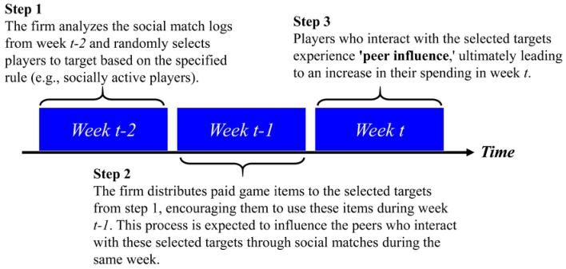

NOTE: figure/graphic rendered as an image from the PDF; its content is not machine-readable text. Caption (if any) follows as the next block.

could use this simple calculus to decide which targeting strategy to adopt as well as understand the cost structures that would facilitate successful strategies.

#### Summary and Intended Contributions

The managerial success of a large freemium-based serv ice requires an understanding of how social influence plays a role in consumer behavior. While there has been signifi cant focus in prior literature toward the role of known peers (friends) or aggregated crowd opinions, little attention has been given to the potential influence that anonymous peers may exert. This is an increasingly important issue given the growing popularity of socially interactive features embedded in many contexts, especially in online video

games. We aim to address this gap in the literature by (1) shining a spotlight on the outsized role that anonymous peers may have in shaping consumer behavior and, more importantly, (2) providing an empirical understanding of theoretical mechanisms driving peer effects.

Using purchase and game log data from a large gaming platform in Korea, we show that peer effects are indeed sig nificant among anonymous players. By investigating the theory behind the effect of strangers, we offer empirical evidence of the theoretical underpinnings (Bursztyn et al. 2014; Gardete 2015; Toker-Yildiz et al. 2017) in the con text of digital goods. We find that, contrary to expectations, peer effects are primarily driven by informational influence (as opposed to competitive concern) even in the empirical context of our competitive game. That is, the influence of anonymous peers decreases as the players accrue more con textual knowledge.

The current research makes three important contribu tions to the academic literature. *First*, our theory-based empirical investigation of the underlying mechanisms of peer influence directly complements existing research on peer effects in consumer behavior. Although the literature on peer influence is extensive and mature, there are rela tively few empirical investigations that explore the mecha nisms of *how* and *why* peer influence operates (see table 1 for details), especially in the online context. Our study identifies the theoretically plausible mechanisms of social effects (Van den Bulte and Lilien 2001) in a video game setting and validates them through a series of robustness checks. Our results reveal that peer influence is most

**FIGURE 5**

VISUAL DESCRIPTION OF CUSTOMER TARGETING

pronounced among users with limited contextual knowl edge, indicating that the primary reasons for following others are to “learn” and “gather” information. That is, even in an adversarial/competitive setting, strangers exert influence on others through the perceived information embedded in their purchases (the informational influence mechanism). Interestingly, we do not find evidence that competitive concern or status threat mechanism drives peer effects.

*Second*, we contribute to the peer effects and social influence literature by examining a unique type of social interaction wherein agent-to-agent interactions are happen stance and where friendship ties are not established. Our work joins a nascent stream of research interested in evalu ating the role of strangers in consumer behavior (Argo et al. 2005; Ferraro et al. 2009; Lusch 2017; Martin 2012). Unlike prior work, which has focused on offline retail and durable good settings (Bollinger et al. 2022; McShane et al. 2012), our work offers unique insights into how stranger interactions influence behavior in online environments.

*Finally*, our work also contributes to the growing litera ture on marketing issues in video games. Revenues from the video game industry have already surpassed those of the movie, music, or professional sports industries (Partin 2020; Witkowski 2021), making it a culturally significant and important business sector. Given the increasing promi nence of social gaming in the industry, understanding the nature of peer influence is of primary importance to video game publishers. Despite its economic and cultural signifi cance, research on consumer behavior in this context remains extremely sparse. Our work provides valuable insights into the mechanisms of peer influence in adversa rial gaming contexts, offering guidance for marketing strat egies and consumer engagement in the field of video gaming.

#### Implications for Practitioners

The implications of this research are germane to manag ers, particularly video game publishers and app developers. Below, we describe the actionable guidance for managers that stem from this work.

1. *Leverage peer influence to boost purchase behav ior*: This research shows that, even in the absence of clearly defined friendship networks, strangers can influence our (online) behaviors in profound ways. This opens up opportunities for firms to lev erage such *stranger interactions* to trigger pur chase behavior in online environments. For instance, our analyses show that the influence from strangers is particularly effective in motivating more frequent purchase incidences (extensive mar gin) but does not necessarily increase the amount spent on each purchase (intensive margin). Video game companies could leverage this by imple menting strategies that encourage repeat purchases. Since peer influence is most effective in driving the decision to make a purchase, **firms should focus on promotional efforts that emphasize fre quent buying opportunities**, especially targeting players with less contextual knowledge who have been exposed to a greater extent of anonymous peers’ spending, rather than trying to increase the spending per transaction. 2. *Product salience increases peer influence*: Our results also directly point to guidance for video game designers interested in effectively leveraging peer influence. A common strategy used in gam ing—encouraging competitions among players— does not necessarily lead to positive outcomes in a social environment. Instead, we recommend prom inently displaying peer purchases during social matches with anonymous peers. Specifically, our

**TABLE 9**

ESTIMATED PERFORMANCES OF INTERVENTIONS

[output not shown]

NOTE: table converted from PDF layout to HTML text; cell boundaries are reconstructed. See PDF if exact alignment matters.

NOTE.—The simulation is based on targeting 500 players randomly selected from the target group and providing them with a $20 paid item for each week. The 95% empirical confidence intervals in squared brackets are derived from 1,000 replications, each involving a different random sample. Mean values are reported as estimates.

findings highlight the importance of **increasing the salience and visibility of in-game item usage by other players during social matches if firms seek to strengthen peer effects**. This approach is advised because the primary source of peer influ ence stems from the visibility of salient items used by anonymous peers, rather than from encouraging users to learn and explore other players’ strategies by observing less salient items. 3. *A simple change in seeding strategies that lever ages the underlying mechanism of peer influence can make a huge difference*: Our simulations show that targeting strategies to seed social influence can have important revenue implications for gam ing companies. Our results suggest that managers need to incorporate peer effects from strangers into their seeding strategy. Even in the absence of con ventional marketing instruments, firms can lever age in-game peer effects by **targeting individuals more likely to amplify informational influence**. Based on our back-of-the-envelope calculations, we find that leveraging informational influence is financially more effective—yielding approxi mately 48% more in terms of revenue lift (table 9)—than relying solely on general social influence.

#### Limitations and Avenues for Future Research

This research is not without its limitations. First, despite the granularity of the data provided, we believe that a cer tain portion of peer influence may stem from word-of- mouth interactions between players. While this still falls under peer influence, it differs from observational learning that occurs without verbal communication (Zhang 2010). Using supplementary data, such as chat logs between play ers, future research in similar settings could aim to disen tangle peer influence into communication-based and non- communication-based types and explore additional impli cations. Second, with additional data such as team lineups, rookie trainings, and other performance metrics, it would be worthwhile to investigate whether peer effects impact users’ gaming performances. Third, we consistently observe a positive and significant main effect of the Threats to Status variable (% inferior matchesit–1). While not the focus of our interest, since managers of video games may be particularly interested in the factors influ encing voluntary purchases, future research could certainly explore this variable theoretically and empirically. Finally, while our context is limited to digital goods consumption, it would certainly be interesting to explore peer effects in other contexts such as offline arcades. We relegate these questions to future research explorations.

#### **DATA COLLECTION STATEMENT**

The proprietary dataset used for this research was pro vided by one of the largest video gaming firms in South Korea, which wishes to remain anonymous. The dataset was directly supplied to the third author by the company in 2013. The first author cleaned and analyzed the data under the supervision of the third author. The dataset is currently stored on the first author’s secured PC. In accordance with the *Journal of Consumer Research*’s Research Ethics, Transparency, and Open Science policy, the authors have clearly communicated to the editorial team that the dataset cannot be publicly shared due to a non-disclosure agree ment. Following the journal’s submission guidelines, the authors have also acknowledged to the editor that a paper published in *Marketing Science* (Jo et al., 2020) also employed data from the same collaborating firm. However, the two papers are fundamentally different in their aims and contributions. The previous paper examined the effect of regulating teens’ access to gaming on game use, whereas this article investigates the role of peer influence in the adoption of paid game products.

#### **REFERENCES**

Ameri, Mina, Elisabeth Honka, and Ying Xie (2019), “Word of

Mouth, Observed Adoptions, and Anime-Watching Decisions: The Role of the Personal vs. the Community Network,” *Marketing Science*, 38 (4), 567–83. Aral, Sinan and Dylan Walker (2012), “Identifying Influential and

Susceptible Members of Social Networks,” *Science (New York, N.Y.)*, 337 (6092), 337–41. Aral, Sinan and Dylan Walker (2014), “Tie Strength,

Embeddedness, and Social Influence: A Large-Scale Networked Experiment,” *Management Science*, 60 (6), 1352–70. Argo, Jennifer J., Darren W. Dahl, and Rajesh V. Manchanda

(2005), “The Influence of a Mere Social Presence in a Retail Context,” *Journal of Consumer Research*, 32 (2), 207–12. Asch, Solomon E. (1953), “Effects of Group Pressure upon the

Modification and Distortion of Judgements,” in *Group Dynamics*, Evanston, IL: Row, Peterson and Company. Bakshy, Eytan, Dean Eckles, Rong Yan, and Itamar Rosenn

(2012), “Social Influence in Social Advertising: Evidence from Field Experiments,” in *EC ’12: Proceedings of the 13th ACM Conference on Electronic Commerce*, ed. Boi Faltings, Valencia, Spain: Association for Computing Machinery. Barron, Kyle, Edward Kung, and Davide Proserpio (2021), “The

Effect of Home-Sharing on House Prices and Rents: Evidence from Airbnb,” *Marketing Science*, 40 (1), 23–47. Behnke, Maciej, Michal Kosakowski, and Lukasz D. Kaczmarek

(2020), “Social Challenge and Threat Predict Performance and Cardiovascular Responses during Competitive Video Gaming,” *Psychology of Sport and Exercise*, 46, 101584. Bikhchandani, Sushil, David Hirshleifer, and Ivo Welch (1992),

“A Theory of Fads, Fashion, Custom, and Cultural-Change as Informational Cascades,” *Journal of Political Economy*, 100 (5), 992–1026.

Bikhchandani, Sushil, David Hirshleifer, and Ivo Welch (1998),

“Learning from the Behavior of Others: Conformity, Fads, and Informational Cascades,” *Journal of Economic Perspectives*, 12 (3), 151–70. Blanchard, Simon J., Tatiana L. Dyachenko, and Keri L. Kettle

(2020), “Locational Choices: Modeling Consumer Preferences for Proximity to Others in Reserved Seating Venues,” *Journal of Marketing Research*, 57 (5), 878–99. Bollinger, Bryan and Kenneth Gillingham (2012), “Peer Effects in

the Diffusion of Solar Photovoltaic Panels,” *Marketing Science*, 31 (6), 900–12. Bollinger, Bryan, Kenneth Gillingham, A. Justin Kirkpatrick, and

Steven Sexton (2022), “Visibility and Peer Influence in Durable Good Adoption,” *Marketing Science*, 41 (3), 453–76. Bramoulle, Yann, Habiba Djebbari, and Bernard Fortin (2009),

“Identification of Peer Effects through Social Networks,” *Journal of Econometrics*, 150 (1), 41–55. Bronnenberg, Bart J. and Carl F. Mela (2004), “Market Roll-Out

and Retailer Adoption for New Brands,” *Marketing Science*, 23 (4), 500–18. Bursztyn, Leonardo, Florian Ederer, Bruno Ferman, and Noam

Yuchtman (2014), “Understanding Mechanisms Underlying Peer Effects: Evidence From a Field Experiment on Financial Decisions,” *Econometrica*, 82 (4), 1273–301. Burt, Ronald S. (1987), “Social Contagion and Innovation:

Cohesion versus Structural Equivalence,” *American Journal of Sociology*, 92 (6), 1287–335. Chen, Zoey (2017), “Social Acceptance and Word of Mouth: How

the Motive to Belong Leads to Divergent WOM with Strangers and Friends,” *Journal of Consumer Research*, 44 (3), 613–32. Clark, Margaret S. and Judson Mills (1979), “Interpersonal

Attraction in Exchange and Communal Relationships,” *Journal of Personality and Social Psychology*, 37 (1), 12–24. Dean, Grace (2020), “Chess.Com Is Seeing 100,000 Sign-Ups a

Day Following the Success of Netflix Series ‘The Queen’s Gambit’—and the Site Is Now Pitting Users against Beth Harmon Bots,” *Business Insider*, November 24. Last Accessed April 30, 2021. https://www.businessinsider.com/the-queens- gambit-netflix-online-chess-app-interest-2020-11. Deutsch, Morton, and Harold B. Gerard (1955), “A Study of

Normative and Informational Social Influences upon Individual Judgment,” *The Journal of Abnormal and Social Psychology*, 51 (3), 629–36. Du, Rex Yuxing and Wagner A. Kamakura (2011), “Measuring

Contagion in the Diffusion of Consumer Packaged Goods,” *Journal of Marketing Research*, 48 (1), 28–47. Dubois, David, Andrea Bonezzi, and Matteo De Angelis (2016),

“Sharing with Friends versus Strangers: How Interpersonal Closeness Influences Word-of-Mouth Valence,” *Journal of Marketing Research*, 53 (5), 712–27. Ferraro, Rosellina, James R. Bettman, and Tanya L. Chartrand

(2009), “The Power of Strangers: The Effect of Incidental Consumer Brand Encounters on Brand Choice,” *Journal of Consumer Research*, 35 (5), 729–41. Gardete, Pedro M. (2015), “Social Effects in the In-Flight

Marketplace: Characterization and Managerial Implications,” *Journal of Marketing Research*, 52 (3), 360–74. Goldenberg, Jacob, Sangman Han, Donald R. Lehmann, and Jae

Weon Hong (2009), “The Role of Hubs in the Adoption Process,” *Journal of Marketing*, 73 (2), 1–13. Goldsmith-Pinkham, Paul and Guido W. Imbens (2013), “Social

Networks and the Identification of Peer Effects,” *Journal of Business & Economic Statistics*, 31 (3), 253–64.

Hannan, Timothy H. and John M. McDowell (1984a), “Market

Concentration and the Diffusion of New Technology in the Banking Industry,” *The Review of Economics and Statistics*, 66 (4), 686–91. Hannan, Timothy H. and John M. McDowell (1984b), “The

Determinants of Technology Adoption: The Case of the Banking Firm,” *The RAND Journal of Economics*, 15 (3), 328–35. Hannan, Timothy H. and John M. McDowell (1987), “Rival

Precedence and the Dynamics of Technology Adoption: An Empirical Analysis,” *Economica*, 54 (214), 155–71. Harmeling, Colleen M., Robert W. Palmatier, Eric (Er) Fang, and

Dainwen Wang (2017), “Group Marketing: Theory, Mechanisms, and Dynamics,” *Journal of Marketing*, 81 (4), 1–24. Hartmann, Wesley R., Puneet Manchanda, Harikesh Nair,

Matthew Bothner, Peter Dodds, David Godes, Kartik Hosanagar, and Catherine Tucker (2008), “Modeling Social Interactions: Identification, Empirical Methods and Policy Implications,” *Marketing Letters*, 19 (3–4), 287–304. Hinz, Oliver, Martin Spann, and Il-Horn Hann (2015), “Research

Note—Can’t Buy Me Love...Or Can I? Social Capital Attainment Through Conspicuous Consumption in Virtual Environments,” *Information Systems Research*, 26 (4), 859–70. Hu, Yansong and Christophe Van den Bulte (2014), “Nonmonotonic Status Effects in New Product Adoption,” *Marketing Science*, 33 (4), 509–33. Iyengar, Raghuram, Christophe Van den Bulte, and Jeonghye Choi

(2011a), “Distinguishing among Mechanisms of Social Contagion in New Product Adoption: Framework and Illustration,” *Marketing Science Institute Working Paper Series*, Cambridge, MA: Marketing Science Institute, 11–119. Iyengar, Raghuram, Christophe Van den Bulte, and Jae Young Lee

(2015), “Social Contagion in New Product Trial and Repeat,” *Marketing Science*, 34 (3), 408–29. Iyengar, Raghuram, Christophe Van den Bulte, and Thomas W

Valente (2011b), “Opinion Leadership and Social Contagion in New Product Diffusion,” *Marketing Science*, 30 (2), 195–212. Jo, Wooyong (2017), “(The) Purchase of Virtual Goods and the Impact

of Social Interaction,” Master Thesis, Graduate School, Yonsei University. Last Accessed May 24, 2021. http://www.riss.kr/ search/detail/DetailView.do?p_mat_type=be54d9b8bc7cdb09 &control_no=e953c47650c17e0dffe0bdc3ef48d419. Jo, Wooyong and Michael Lewis (2024), “Sponsored Product-

Based Competition and Customer Engagement: A Study of an Esports Competition in the Video Game Industry,” *Production and Operations Management*, 33 (3), 795–816. Jo, Wooyong and Michael Lewis (2025), “How Expansion to the

Nintendo Switch Impacts PC Players’ Game Usage and Spending: A Study of an Omni-Channel Strategy,” *International Journal of Research in Marketing*. Last Accessed November 18, 2024. https://www.sciencedirect. com/science/article/pii/S0167811624000958. Jo, Wooyong, Sarang Sunder, Jeonghye Choi, and Minakshi

Trivedi (2020), “Protecting Consumers from Themselves: Assessing Consequences of Usage Restriction Laws on Online Game Usage and Spending,” *Marketing Science*, 39 (1), 117–33. Lanz, Andreas, Jacob Goldenberg, Daniel Shapira, and Florian

Stahl (2019), “Climb or Jump: Status-Based Seeding in User- Generated Content Networks,” *Journal of Marketing Research*, 56 (3), 361–78.

Lusch, Robert F. (2017), “The Long Macro View,” *Journal of*

*Macromarketing*, 37 (3), 321–3. Mackie, Diane and Joel Cooper (1984), “Attitude Polarization—

Effects of Group Membership,” *Journal of Personality and Social Psychology*, 46 (3), 575–85. Manski, Charles F. (1993), “Identification of Endogenous Social

Effects: The Reflection Problem,” *The Review of Economic Studies*, 60 (3), 531–42. Martin, Brett A. S. (2012), “A Stranger’s Touch: Effects of

Accidental Interpersonal Touch on Consumer Evaluations and Shopping Time,” *Journal of Consumer Research*, 39 (1), 174–84. McShane, Blakeley B., Eric T. Bradlow, and Jonah Berger (2012),

“Visual Influence and Social Groups,” *Journal of Marketing Research*, 49 (6), 854–71. Mu, Jifeng, Ellen Thomas, Jiayin Qi, and Yong Tan (2018), “Online

Group Influence and Digital Product Consumption,” *Journal of the Academy of Marketing Science*, 46 (5), 921–47. Nair, Harikesh S., Puneet Manchanda, and Tulikaa Bhatia (2010),

“Asymmetric Social Interactions in Physician Prescription Behavior: The Role of Opinion Leaders,” *Journal of Marketing Research*, 47 (5), 883–95. Narayanan, Sridhar and Harikesh S. Nair (2013), “Estimating

Causal Installed-Base Effects: A Bias-Correction Approach,” *Journal of Marketing Research*, 50 (1), 70–94. Nokes, Timothy J. and Stellan Ohlsson (2005), “Comparing

Multiple Paths to Mastery: What Is Learned?,” *Cognitive Science*, 29 (5), 769–96. Papies, Dominik, Peter Ebbes, and Harald J. Van Heerde (2017),

“Addressing Endogeneity in Marketing Models,” in *Advanced Methods for Modeling Markets*, ed. Peter S. H. Leeflang, Jaap E. Wieringa, Tammo H.A Bijmolt, and Koen H. Pauwels, Cham: Springer International Publishing, 581–627. Last Accessed February 24, 2024. https://link. springer.com/book/10.1007/978-3-319-53469-5 Park, Eunho, Rishika Rishika, Ramkumar Janakiraman, Mark B.

Houston, and Byungjoon Yoo (2018), “Social Dollars in Online Communities: The Effect of Product, User, and Network Characteristics,” *Journal of Marketing*, 82 (1), 93–114. Partin, Will (2020), “Analysis j The 2010s Were a Banner Decade

for Big Money and Tech—and Esports Reaped the Rewards,” *Washington Post*, January 28. Last Accessed October 25, 2023. https://www.washingtonpost.com/video-games/ esports/2020/01/28/2010s-were-banner-decade-big-money- tech-esports-reaped-rewards/. Peng, Jing, Ashish Agarwal, Kartik Hosanagar, and Raghuram

Iyengar (2018), “Network Overlap and Content Sharing on Social Media Platforms,” *Journal of Marketing Research*, 55 (4), 571–85. Rishika, Rishika and Jui Ramaprasad (2019), “The Effects of

Asymmetric Social Ties, Structural Embeddedness, and Tie Strength on Online Content Contribution Behavior,” *Management Science*, 65 (7), 3398–422. Rogers, Everett M. (1995), “Diffusion of Innovations: Modifications of a Model for Telecommunications,” in *Die Diffusion von Innovationen in Der Telekommunikation*, ed. Matthias-W. Stoetzer and Alwin Mahler, Berlin, Heidelberg: Springer, 25–38. Salganik, Matthew J., Peter Sheridan Dodds, and Duncan J. Watts

(2006), “Experimental Study of Inequality and Unpredictability in an Artificial Cultural Market,” *Science (New York, N.Y.)*, 311 (5762), 854–6.

Sanderson, Eleanor and Frank Windmeijer (2016), “A Weak Instrument

F-Test in Linear IV Models with Multiple Endogenous Variables,” *Journal of Econometrics*, 190 (2), 212–21. Shen, Jie, Alan J. Malter, and Aric Rindfleisch (2023),

“Transacting with Strangers in a Digital World,” *Journal of Macromarketing*, 43 (1), 76–84. Shi, Huanhuan, Rajdeep Grewal, and Shrihari Sridhar (2021),

“Organizational Herding in Advertising Spending Disclosures: Evidence and Mechanisms,” *Journal of Marketing Research*, 58 (3), 515–38. Simonov, Andrey, Raluca M. Ursu, and Carolina Zheng (2023),

“Suspense and Surprise in Media Product Design: Evidence from Twitch,” *Journal of Marketing Research*, 60 (1), 1–24. Sridhar, Shrihari and Raji Srinivasan (2012), “Social Influence Effects

in Online Product Ratings,” *Journal of Marketing*, 76 (5), 70–88. Sun, Monic, Xiaoquan (Michael) Zhang, and Feng Zhu (2019),

“U-Shaped Conformity in Online Social Networks,” *Marketing Science*, 38 (3), 461–80. Sunder, Sarang, Kihyun Hannah Kim, and Eric A. Yorkston

(2019), “What Drives Herding Behavior in Online Ratings? The Role of Rater Experience, Product Portfolio, and Diverging Opinions,” *Journal of Marketing*, 83 (6), 93–112. Toker-Yildiz, Kamer, Minakshi Trivedi, Jeonghye Choi, and Sue

Ryung Chang (2017), “Social Interactions and Monetary Incentives in Driving Consumer Repeat Behavior,” *Journal of Marketing Research*, 54 (3), 364–80. Tucker, Catherine and Juanjuan Zhang (2011), “How Does

Popularity Information Affect Choices? A Field Experiment,” *Management Science*, 57 (5), 828–42. Van den Bulte, Christophe and Stefan Wuyts (2009), “Leveraging

Customer Networks,” in *The Network Challenge: Strategy, Profit, and Risk in an Interlinked World*, ed. Paul R. Kleindorfer, Yoram Wind, and Robert E. Gunther, Upper Saddle River, NJ: Pearson, 243–59. Van den Bulte, Christophe and Gary L. Lilien (2001), “Medical

Innovation Revisited: Social Contagion versus Marketing Effort,” *American Journal of Sociology*, 106 (5), 1409–35. Wang, Kitty and Avi Goldfarb (2017), “Can Offline Stores Drive

Online Sales?,” *Journal of Marketing Research*, 54 (5), 706–19. White, Katherine and Bonnie Simpson (2013), “When Do (and

Don’t) Normative Appeals Influence Sustainable Consumer Behaviors?,” *Journal of Marketing*, 77 (2), 78–95. Witkowski, Wallace (2021), “Videogames Are a Bigger Industry

than Movies and North American Sports Combined, Thanks to the Pandemic,” *MarketWatch*, January 2. Last Accessed October 25, 2023. https://www.marketwatch.com/story/vid eogames-are-a-bigger-industry-than-sports-and-movies-com bined-thanks-to-the-pandemic-11608654990. Wooldridge, Jeffrey M. (2015), “Control Function Methods in

Applied Econometrics,” *Journal of Human Resources*, 50 (2), 420–45. Wooten, David B. and Americus Reed II (2004), “Playing It Safe:

Susceptibility to Normative Influence and Protective Self- Presentation,” *Journal of Consumer Research*, 31 (3), 551–6. Zhang, Juanjuan (2010), “The Sound of Silence: Observational

Learning in the U.S. Kidney Market,” *Marketing Science*, 29 (2), 315–35. Zhang, Jurui, Yong Liu, and Yubo Chen (2015), “Social Learning

in Networks of Friends versus Strangers,” *Marketing Science*, 34 (4), 573–89. Zhang, Yuchi and David Godes (2018), “Learning from Online

Social Ties,” *Marketing Science*, 37 (3), 425–44.